# Praca domowa 6

Ola Paluszynska

10 kwietnia 2017

## Dane do zadania

Pobieramy plik `df.rda` i wykonaj na nim następujące zadania.

```r
setwd("~/UW/Modele_Liniowe_i_Mieszane")
load("df.rda")
library(ggplot2)
library(e1071)
library(MASS)
library(lmtest)
library(moments)
library(car)
library(partykit)
```

## 1. Wykonaj analizę jednokierunkową wariancji ze zmienną `V1`. Ustaw poziom `B` jako poziom referencyjny.

```r
df <- within(df, V1 <- relevel(V1, ref = 2))
summary(model1 <- lm(y ~ V1, data = df))
```

```
##
## Call:
## lm(formula = y ~ V1, data = df)
##
## Residuals:
##     Min      1Q  Median      3Q     Max
## -13.258  -6.339  -1.739   6.110  18.245
##
## Coefficients:
##             Estimate Std. Error t value Pr(>|t|)
## (Intercept)  24.0987     0.7538   31.97   <2e-16 ***
## V1A         -14.9776     1.0660  -14.05   <2e-16 ***
## V1C         -15.7926     1.0660  -14.81   <2e-16 ***
## ---
## Signif. codes:  0 '***' 0.001 '**' 0.01 '*' 0.05 '.' 0.1 ' ' 1
##
## Residual standard error: 7.538 on 297 degrees of freedom
## Multiple R-squared:  0.4838, Adjusted R-squared:  0.4803
## F-statistic: 139.2 on 2 and 297 DF,  p-value: < 2.2e-16
```

```r
anova(model1)
```

```
## Analysis of Variance Table
##
## Response: y
##            Df Sum Sq Mean Sq F value    Pr(>F)
## V1          2  15813  7906.6  139.16 < 2.2e-16 ***
## Residuals 297  16874    56.8
## ---
## Signif. codes:  0 '***' 0.001 '**' 0.01 '*' 0.05 '.' 0.1 ' ' 1
```

```r
df <- within(df, V1 <- relevel(V1, ref = 2))
```

Na podstawie powyższego testu istotności stwierdzamy, że nawet przy poziomie istotności 0.01 model ze zmienną `V1` jest istotnie lepszy od modelu z pustego (z samą stałą).

## 2. Połącz w zmiennych `V1` i `V2` poziomy `B` i `C` ze sobą, a następnie wykonaj test weryfikujący istotność interakcji.

```r
df$V1_2 <- factor(as.numeric(df$V1), levels = 1:3, labels = c("A", "B+C", "B+C"))
df$V1_2 <- droplevels(df$V1_2)
df$V2_2 <- factor(as.numeric(df$V2), levels = 1:3, labels = c("A", "B+C", "B+C"))
df$V2_2 <- droplevels(df$V2_2)
anova(lm(y ~ V1_2*V2_2, data = df))
```

```
## Analysis of Variance Table
##
## Response: y
##            Df  Sum Sq Mean Sq F value    Pr(>F)
## V1_2        1  3343.0  3343.0 34.1446 1.348e-08 ***
## V2_2        1   210.2   210.2  2.1468    0.1439
## V1_2:V2_2   1   153.7   153.7  1.5701    0.2112
## Residuals 296 28980.5    97.9
## ---
## Signif. codes:  0 '***' 0.001 '**' 0.01 '*' 0.05 '.' 0.1 ' ' 1
```

```r
anova(lm(y ~ V2_2*V1_2, data = df))
```

```
## Analysis of Variance Table
##
## Response: y
##            Df  Sum Sq Mean Sq F value    Pr(>F)
## V2_2        1   342.6   342.6  3.4992   0.06238 .
## V1_2        1  3210.6  3210.6 32.7922 2.518e-08 ***
## V2_2:V1_2   1   153.7   153.7  1.5701   0.21118
## Residuals 296 28980.5    97.9
## ---
## Signif. codes:  0 '***' 0.001 '**' 0.01 '*' 0.05 '.' 0.1 ' ' 1
```

Jak widać interakcja zmiennych `V1` i `V2` po połączeniu poziomów B i C nie jest istotna w teście sekwencyjnym po włączeniu składowych interakcji do modelu (istotność poszczególnych zmiennych jest natomiast zależna od kolejności ich włączania do modelu). Brak tej istotności może wynikać ze stosunkowo niewielkiej próby – zauważmy, że poniższy interaction plot sugeruje występowanie interakcji, gdyż dwie linie przecinają się:

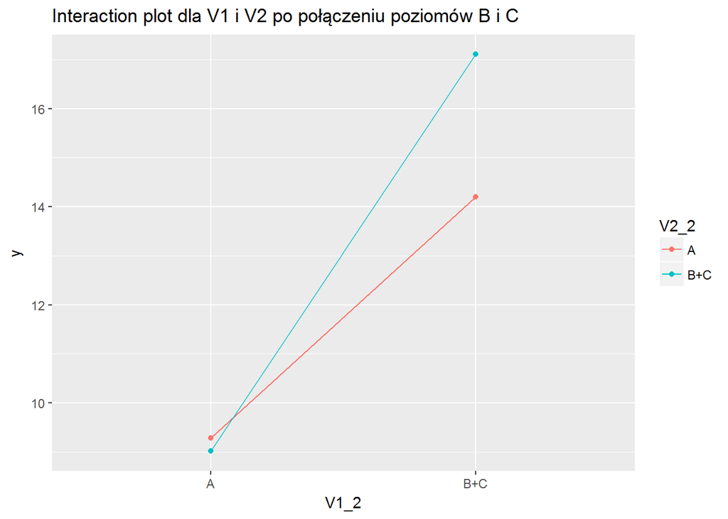

```r
ggplot(df, aes(x = V1_2, y = y, color = V2_2, group = V2_2)) + stat_summary(fun.y = mean, geom = "line") + stat_summary(fun.y = mean, geom = "point") + ggtitle("Interaction plot dla V1 i V2 po połączeniu poziomów B i C")
```

Oczywiście, gdyby nie uwzględnić w testowaniu sekwencyjnym składników interakcji, to będzie ona istotna, jako że niesie ona informację związaną z istotnymi pojedynczymi zmiennymi:

```r
anova(lm(y ~ V1_2:V2_2, data = df))
```

```
## Analysis of Variance Table
##
## Response: y
##            Df  Sum Sq Mean Sq F value    Pr(>F)
## V1_2:V2_2   3  3706.9 1235.64   12.62 8.716e-08 ***
## Residuals 296 28980.5   97.91
## ---
## Signif. codes:  0 '***' 0.001 '**' 0.01 '*' 0.05 '.' 0.1 ' ' 1
```

Powyższego wyniku nie należy interpretować jako istotność interakcji.

## 3. Dla zmiennej `V1` porównaj wyniki dla różnych kontrastów, przynajmniej Helmerta, poly i sum.

```r
options()$contrasts
```

```
##         unordered           ordered
## "contr.treatment"      "contr.poly"
```

```r
contrs <- apropos("contr\\.")
coefs <- sapply(contrs, function(i) lm(y ~ V1, data = df, contrasts = list(V1 = get(i)))$coefficients)
t(coefs)
```

```
##                 (Intercept)        V11         V12
## contr.helmert     13.841935  7.4887969  -2.7679211
## contr.Helmert     13.841935  7.4887969  -2.7679211
## contr.poly        13.841935 -0.5762681 -12.5618627
## contr.SAS          8.306093  0.8149662  15.7925601
## contr.sdif        13.841935 14.9775939 -15.7925601
## contr.sum         13.841935 -4.7208759  10.2567180
## contr.Sum         13.841935 -4.7208759  10.2567180
## contr.treatment    9.121059 14.9775939  -0.8149662
## contr.Treatment    9.121059 14.9775939  -0.8149662
```

W przypadku kontrastów poly widzimy, że średnio średnia `y` maleje wraz z osiąganiem kolejnych kategorii zmiennej `V1`, przy czym zależność ta jest znacznie mniejsza co do wartości bezwzględnej od zależności średniej `y` od czynnika kwadratowego.

Wreszcie, standardowe kontrasty (`treatment`) pozwalają nam stwierdzić, że średnia w grupie `B` jest wyższa, a w grupie `C` niższa niż w grupie referencyjnej `A`.

Oczywiście powyższe komentarze pomijają kwestię istotności. Np. dla kontrastów poly poniższy wynik informuje nas o istotności trendu kwadratowego w badanej zależności i nieistotności trendu liniowego.

```r
summary(lm(y ~ V1, data = df, contrasts = list(V1 = contr.poly)))
```

```
##
## Call:
## lm(formula = y ~ V1, data = df, contrasts = list(V1 = contr.poly))
##
## Residuals:
##     Min      1Q  Median      3Q     Max
## -13.258  -6.339  -1.739   6.110  18.245
##
## Coefficients:
##             Estimate Std. Error t value Pr(>|t|)
## (Intercept)  13.8419     0.4352  31.807   <2e-16 ***
## V1.L         -0.5763     0.7538  -0.765    0.445
## V1.Q        -12.5619     0.7538 -16.666   <2e-16 ***
## ---
## Signif. codes:  0 '***' 0.001 '**' 0.01 '*' 0.05 '.' 0.1 ' ' 1
##
## Residual standard error: 7.538 on 297 degrees of freedom
## Multiple R-squared:  0.4838, Adjusted R-squared:  0.4803
## F-statistic: 139.2 on 2 and 297 DF,  p-value: < 2.2e-16
```

## 4. Wykonaj test post hoc dla zmiennej `V3`. Które poziomy różnią się pomiędzy sobą?

Pokazane poniżej wyniki testu $t$ wskazują na brak istotnych różnic między każdą parą poziomów zmiennej `V3`.

```r
pairwise.t.test(df$y, df$V3)$p.value
```

```
##   A  B  C  D  E  F  G         H  I
## B 1 NA NA NA NA NA NA        NA NA
## C 1  1 NA NA NA NA NA        NA NA
## D 1  1  1 NA NA NA NA        NA NA
## E 1  1  1  1 NA NA NA        NA NA
## F 1  1  1  1  1 NA NA        NA NA
## G 1  1  1  1  1  1 NA        NA NA
## H 1  1  1  1  1  1  1        NA NA
## I 1  1  1  1  1  1  1 1.0000000 NA
## J 1  1  1  1  1  1  1 0.9364484  1
```

Dla pewności poniżej wykonujemy również test Tukeya:

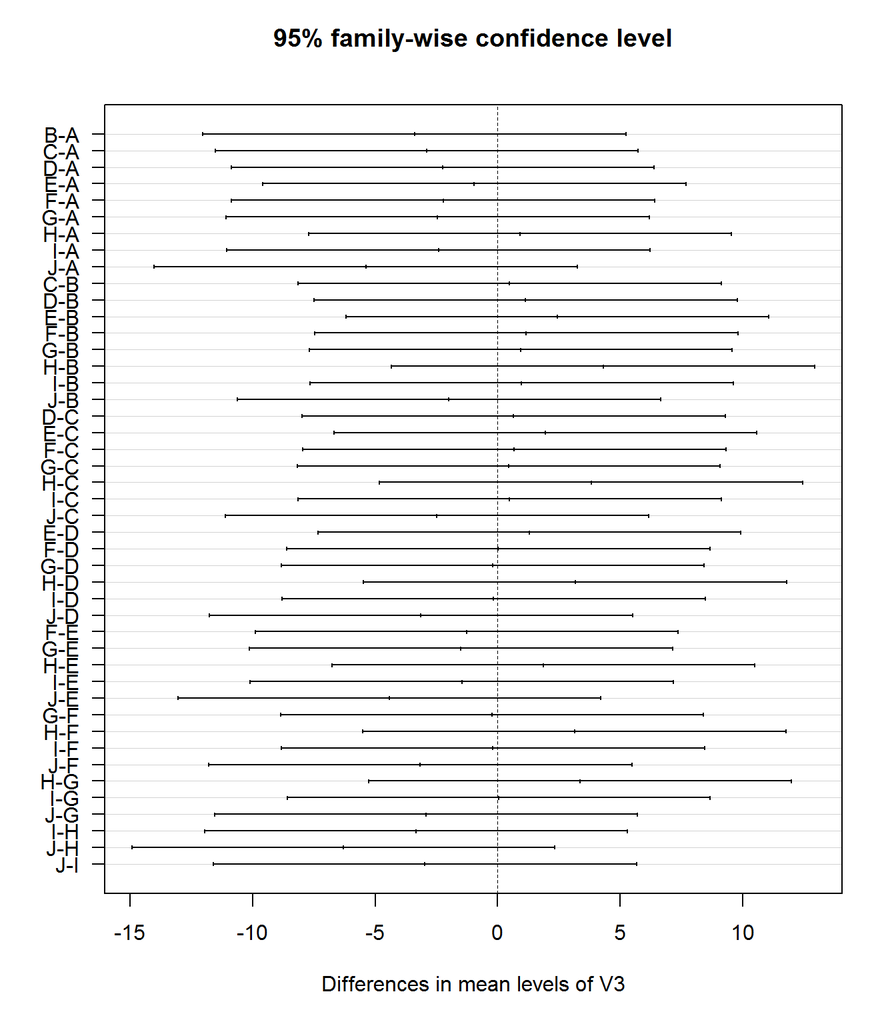

```r
plot(TukeyHSD(aov(y ~ V3, data = df)), las=1)
```

Również ten test nie pozwala stwierdzić istotności różnicy między jakąkolwiek parą poziomów, co może być spowodowane jest to małą liczebnością każdej z grup:

```r
table(df$V3)
```

```
##
##  A  B  C  D  E  F  G  H  I  J
## 30 30 30 30 30 30 30 30 30 30
```

## 5. Zweryfikuj istotność zależności od zmiennej `V4`

Zmienna `V4` jest numeryczna, więc do zbadania istotności wystarczy zwykły test $t$ (niekoniecznie $F$).

```r
summary(model2 <- lm(y ~ V4, data = df))
```

```
##
## Call:
## lm(formula = y ~ V4, data = df)
##
## Residuals:
##      Min       1Q   Median       3Q      Max
## -16.6935  -9.2155   0.5815   6.9727  27.5147
##
## Coefficients:
##             Estimate Std. Error t value Pr(>|t|)
## (Intercept)   12.042      1.179  10.214   <2e-16 ***
## V4             3.696      2.082   1.775   0.0768 .
## ---
## Signif. codes:  0 '***' 0.001 '**' 0.01 '*' 0.05 '.' 0.1 ' ' 1
##
## Residual standard error: 10.42 on 298 degrees of freedom
## Multiple R-squared:  0.01047,    Adjusted R-squared:  0.007146
## F-statistic: 3.152 on 1 and 298 DF,  p-value: 0.07685
```

Zależność zmiennej `y` od `V4` jest istotna tylko jeśli przyjmiemy dość wysoki poziom istotności 0.1. Przy standardowym 0.05 nie mamy podstaw do odrzucenia hipotezy zerowej o braku zależności.

## 6. Czy istotna jest interakcja pomiędzy V4 a V1? Jak pokazać tę zależność.

Poniżej wykonujemy testy sekwencyjne istotności interakcji po włączeniu jej składowych do modelu.

```r
anova(lm(y ~ V1*V4, data = df))
```

```
## Analysis of Variance Table
##
## Response: y
##            Df  Sum Sq Mean Sq  F value Pr(>F)
## V1          2 15813.2  7906.6 140.0805 <2e-16 ***
## V4          1    83.5    83.5   1.4790 0.2249
## V1:V4       2   196.3    98.1   1.7388 0.1775
## Residuals 294 16594.4    56.4
## ---
## Signif. codes:  0 '***' 0.001 '**' 0.01 '*' 0.05 '.' 0.1 ' ' 1
```

```r
anova(lm(y ~ V4*V1, data = df))
```

```
## Analysis of Variance Table
##
## Response: y
##            Df  Sum Sq Mean Sq  F value  Pr(>F)
## V4          1   342.1   342.1   6.0616 0.01439 *
## V1          2 15554.6  7777.3 137.7892 < 2e-16 ***
## V4:V1       2   196.3    98.1   1.7388 0.17754
## Residuals 294 16594.4    56.4
## ---
## Signif. codes:  0 '***' 0.001 '**' 0.01 '*' 0.05 '.' 0.1 ' ' 1
```

Widać, że model z interakcją i jej składowymi nie jest istotnie lepszy od modelu z samymi składowymi, a więc interakcja nie jest istotna. Pokazać tę zależność można za pomocą wykresu regresji objaśniającej `y` zmienną `V4` w grupach ze względu na zmienną `V1`:

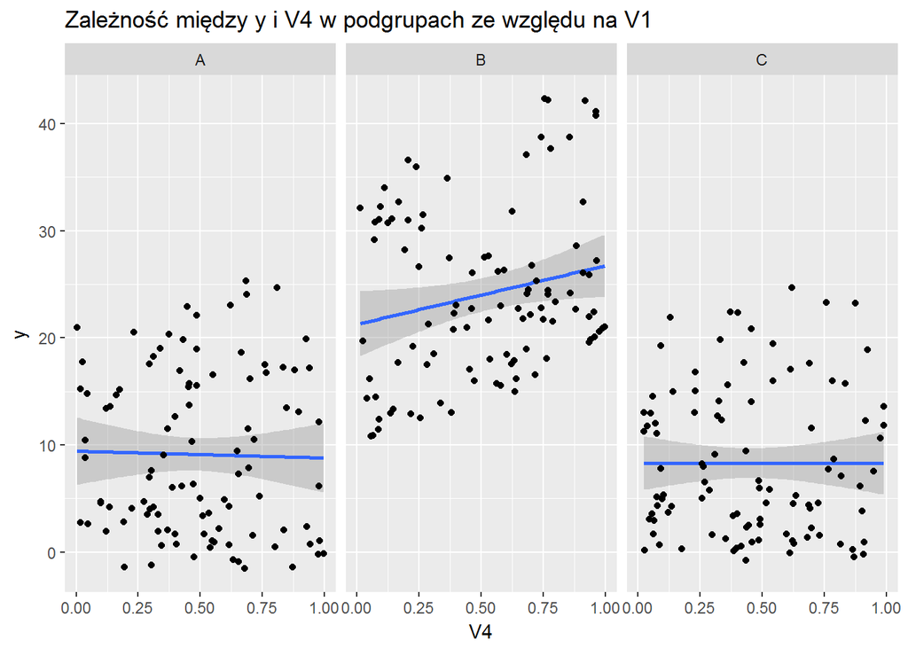

```r
ggplot(df, aes(x = V4, y = y)) + stat_smooth(method=lm) + geom_point() +ggtitle("Zależność między y i V4 w podgrupach ze względu na V1") + facet_grid(. ~ V1)
```

Na powyższym wykresie widać, że prosta regresji wygląda inaczej wśród jednostek, dla których `V1=B` niż wśród pozostałych, co sugeruje istotność interakcji. Warto jednak zaznaczyć, że w modelu z interakcją do modelu regresji włączamy również samą zmienną `V1` co nie jest odzwierciedlone na tym wykresie.

## 7. Zweryfikuj zależność od zmiennej `V5`. A co jeżeli ta zależność nie jest liniowa? Sprawdź zależność od wielomianu stopnia 3.

Poniżej widać, że liniowa zależność między (ilościową) zmienną `V5` a zmienną `y` jest nieistotna dla każdego sensownego poziomu istotności.

```r
summary(lm(y ~ V5, data = df))
```

```
##
## Call:
## lm(formula = y ~ V5, data = df)
##
## Residuals:
##     Min      1Q  Median      3Q     Max
## -15.380  -9.580  -0.122   7.444  29.076
##
## Coefficients:
##             Estimate Std. Error t value Pr(>|t|)
## (Intercept)  13.8584     0.6050  22.907   <2e-16 ***
## V5           -0.7885     1.3535  -0.583    0.561
## ---
## Signif. codes:  0 '***' 0.001 '**' 0.01 '*' 0.05 '.' 0.1 ' ' 1
##
## Residual standard error: 10.47 on 298 degrees of freedom
## Multiple R-squared:  0.001137,   Adjusted R-squared:  -0.002214
## F-statistic: 0.3393 on 1 and 298 DF,  p-value: 0.5607
```

Okazuje się, że powyższa nieistotność wynika z nieliniowości badanej zależności. Uwzględnienie w modelu wielomianu stopnia 3 zmiennej `V5` daje następujący wynik:

```r
summary(lm(y ~ poly(V5, 3), data = df))
```

```
##
## Call:
## lm(formula = y ~ poly(V5, 3), data = df)
##
## Residuals:
##    Min     1Q Median     3Q    Max
## -8.176 -5.598 -4.141  7.145 16.273
##
## Coefficients:
##              Estimate Std. Error t value Pr(>|t|)
## (Intercept)    13.842      0.436  31.747   <2e-16 ***
## poly(V5, 3)1   -6.098      7.552  -0.807    0.420
## poly(V5, 3)2  125.549      7.552  16.625   <2e-16 ***
## poly(V5, 3)3    2.572      7.552   0.341    0.734
## ---
## Signif. codes:  0 '***' 0.001 '**' 0.01 '*' 0.05 '.' 0.1 ' ' 1
##
## Residual standard error: 7.552 on 296 degrees of freedom
## Multiple R-squared:  0.4836, Adjusted R-squared:  0.4783
## F-statistic: 92.39 on 3 and 296 DF,  p-value: < 2.2e-16
```

Istotność części kwadratowej sugeruje, że zależność między zmiennymi jest kwadratowa.

## 8. Zbuduj nową zmienną `NV := V4 - 2*V5`. Zbadaj związek z tą zmienną.

```r
df$NV <- df$V4 - 2*df$V5
summary(lm(y ~ NV, data = df))
```

```
##
## Call:
## lm(formula = y ~ NV, data = df)
##
## Residuals:
##      Min       1Q   Median       3Q      Max
## -15.5025  -9.6155   0.1225   7.2724  29.3224
##
## Coefficients:
##             Estimate Std. Error t value Pr(>|t|)
## (Intercept)  13.5348     0.6665  20.309   <2e-16 ***
## NV            0.6897     0.6350   1.086    0.278
## ---
## Signif. codes:  0 '***' 0.001 '**' 0.01 '*' 0.05 '.' 0.1 ' ' 1
##
## Residual standard error: 10.45 on 298 degrees of freedom
## Multiple R-squared:  0.003943,   Adjusted R-squared:  0.0006007
## F-statistic:  1.18 on 1 and 298 DF,  p-value: 0.2783
```

Stworzona powyżej zmienna nie jest istotna.

## 9. Wybierz model optymalny według kryterium BIC - zrób przegląd pełny wszystkich modeli.

Poniżej porównujemy wszystkie możliwe modele zawierające orginalne zmienne ze zbioru lub/i wielomian stopnia 2 zmiennej `V5`, który był istotny w poprzednich rozważaniach.

```r
zm <- c(colnames(df[, -c(1, 6, 12:14)]), "poly(V5,2)")
wsp = (bincombinations(length(zm)) == 1)[-1,]
params = matrix(0, nrow(wsp), 4)
for (i in 1:nrow(wsp)) {
     form = as.formula(paste("y ~ ", paste(zm[wsp[i,]], collapse="+")))
     model = lm(form, data = df)
     params[i,1] = AIC(model, k = log(nrow(df)))
     params[i,2] = model$rank
     params[i,3] = summary(model)$adj.r.squared
     params[i,4] = AIC(model)
}
as.formula(paste("y ~ ",paste(zm[wsp[which.min(params[,1]),]], collapse="+")))
```

```
## y ~ V1 + V4 + poly(V5, 2)
```

Powyżej przedstawiliśmy optymalny model według kryterium BIC.

## 10. Wybierz model optymalny według kryterium AIC - użyj funkcji step.

```r
stepAIC(lm(as.formula(paste("y ~ ", paste(zm, collapse="+"))), data = df), direction = "both")
```

```
## Start:  AIC=354.44
## y ~ V1 + V2 + V3 + V4 + V6 + V7 + V8 + V9 + V10 + poly(V5, 2)
##
##               Df Sum of Sq     RSS     AIC
## - V2           2       0.5   844.9  350.62
## - V3           9      46.0   890.3  352.34
## - V7           1       0.1   844.5  352.48
## - V6           1       0.4   844.8  352.59
## - V10          1       1.1   845.4  352.82
## - V9           1       4.5   848.8  354.03
## <none>                       844.4  354.44
## - V8           1       7.2   851.5  354.97
## - V4           1     342.1  1186.4  454.48
## - V1           2   14692.3 15536.6 1224.15
## - poly(V5, 2)  2   14912.9 15757.3 1228.38
##
## Step:  AIC=350.62
## y ~ V1 + V3 + V4 + V6 + V7 + V8 + V9 + V10 + poly(V5, 2)
##
##               Df Sum of Sq     RSS     AIC
## - V3           9      46.2   891.0  348.58
## - V7           1       0.1   845.0  348.67
## - V6           1       0.6   845.4  348.82
## - V10          1       1.1   845.9  349.00
## - V9           1       4.5   849.4  350.21
## <none>                       844.9  350.62
## - V8           1       7.4   852.3  351.24
## + V2           2       0.5   844.4  354.44
## - V4           1     342.8  1187.6  450.78
## - V1           2   14825.6 15670.5 1222.73
## - poly(V5, 2)  2   14976.7 15821.6 1225.60
##
## Step:  AIC=348.58
## y ~ V1 + V4 + V6 + V7 + V8 + V9 + V10 + poly(V5, 2)
##
##               Df Sum of Sq     RSS     AIC
## - V6           1       0.0   891.0  346.58
## - V7           1       0.3   891.3  346.67
## - V10          1       0.5   891.5  346.74
## - V9           1       4.7   895.7  348.16
```

[output cut: 56 more lines]

```
## Step:  AIC=342.41
## y ~ V1 + V4 + V8 + poly(V5, 2)
##
##               Df Sum of Sq     RSS     AIC
## <none>                       896.5  342.41
## + V9           1       4.7   891.8  342.84
## - V8           1       7.5   903.9  342.89
## + V7           1       0.4   896.1  344.29
## + V10          1       0.3   896.1  344.29
## + V6           1       0.0   896.5  344.41
## + V3           9      45.6   850.9  344.76
## + V2           2       0.8   895.6  346.13
## - V4           1     347.0  1243.5  438.58
## - V1           2   15055.5 15952.0 1202.07
## - poly(V5, 2)  2   15883.2 16779.7 1217.24
```

```
##
## Call:
## lm(formula = y ~ V1 + V4 + V8 + poly(V5, 2), data = df)
##
## Coefficients:
##  (Intercept)           V1B           V1C            V4            V8
##       6.9465       15.3996        0.3046        3.7523       -0.1636
## poly(V5, 2)1  poly(V5, 2)2
##       5.0935      126.4910
```

Jak widać, krokowa procedura według kryterium AIC daje model podobny do modelu optymalnego według BIC (dodatkowo zawiera zmienną `V8`).

## 11. Wykonaj diagnostykę reszt. Czy są obserwacje odstające/wpływowe?

```r
modelBIC <- lm(y ~ V1 + V4 + poly(V5, 2), data = df)
modelAIC <- lm(y ~ V1 + V4 + V8 + poly(V5, 2), data = df)
reszty <- rbind(data.frame(reszty = rstudent(modelBIC), model = "Model BIC"), data.frame(reszty = rstudent(modelAIC), model = "Model AIC")) # wyznaczamy reszty studentyzowane
```

### Jednorodność wariancji

Poniższe wykresy pokazują, że wariancja reszt jest wyższa dla wyższych wartości dopasowanych co wskazuje na niespełnienie założenia o jednorodności wariancji.

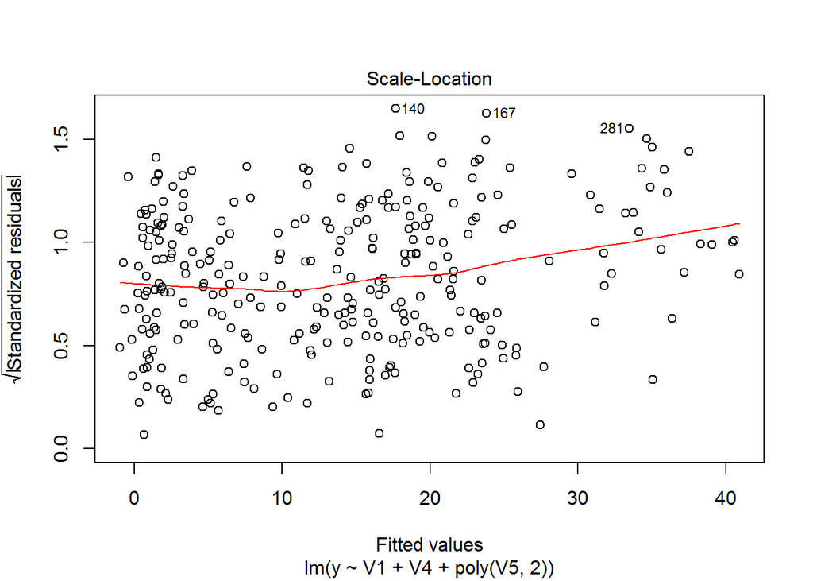

```r
plot(modelBIC, which = 3)
```

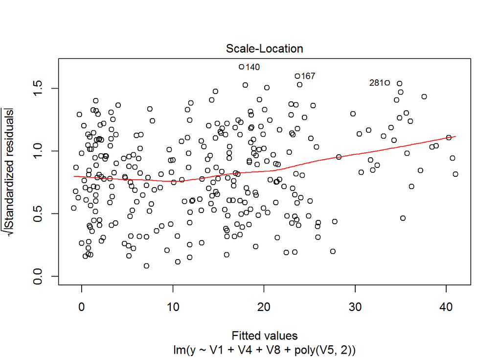

```r
plot(modelAIC, which = 3)
```

Powyższa obserwacja nie znajduje potwierdzenia w teście Goldfeldaa-Quandta dla modelu BIC, ale znajduje potwierdzenie dla modelu AIC (przyjmując poziom istotności 0.05), czyli pierwszy z modeli jest lepszy.

```r
gqtest(modelBIC, order.by = ~ V4, data = df)
```

```
##
##  Goldfeld-Quandt test
##
## data:  modelBIC
## GQ = 1.2771, df1 = 144, df2 = 144, p-value = 0.07168
## alternative hypothesis: variance increases from segment 1 to 2
```

```r
gqtest(modelAIC, order.by = ~ V4, data = df)
```

```
##
##  Goldfeld-Quandt test
##
## data:  modelAIC
## GQ = 1.3882, df1 = 143, df2 = 143, p-value = 0.02538
## alternative hypothesis: variance increases from segment 1 to 2
```

Warto zaznaczyć, że szeregowanie danych względem dowolnej innej zmiennej objaśniającej nie prowadzi do odrzucenia hipotezy zerowej.

### Brak autokorelacji reszt

Obok jednorodności wariancji ważnym założeniem modelu regresji liniowej jest brak autokorelacji reszt, który badamy stosując test Breuscha-Godfrey’a rzędu 4.

```r
bgtest(modelBIC, order.by = ~ V4, order = 4, data = df)
```

```
##
##  Breusch-Godfrey test for serial correlation of order up to 4
##
## data:  modelBIC
## LM test = 3.6999, df = 4, p-value = 0.4481
```

```r
bgtest(modelAIC, order.by = ~ V4, order = 4, data = df)
```

```
##
##  Breusch-Godfrey test for serial correlation of order up to 4
##
## data:  modelAIC
## LM test = 4.2046, df = 4, p-value = 0.379
```

### Normalność rozkładu reszt

Poniży histogram sugeruje dość dobre dopasowanie rozkładu reszt studentyzowanych w każdym z modeli do rozkładu normalnego o odpowiednich momentach:

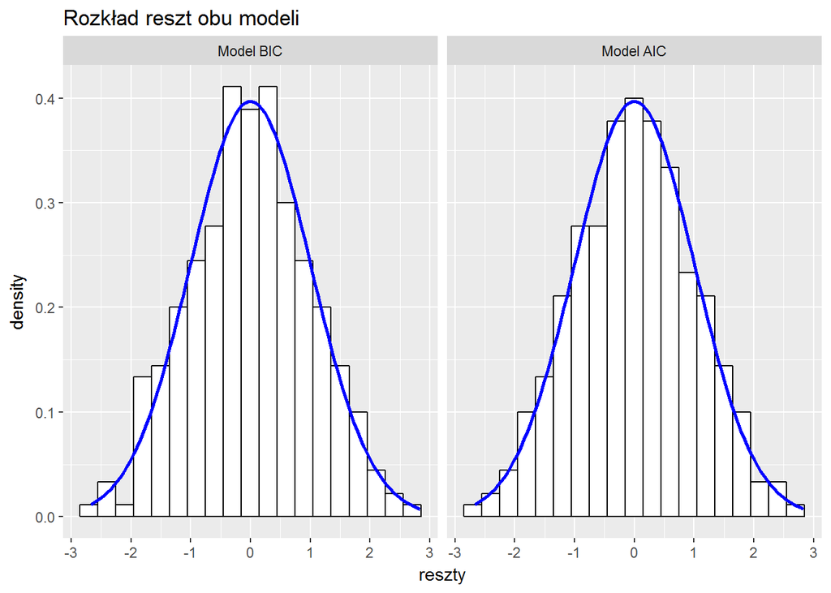

```r
ggplot(reszty, aes(x = reszty)) + geom_histogram(aes(y=..density..), binwidth = 0.3, color = "black", fill = "white") + stat_function(fun = dnorm, args = list(mean = mean(reszty$reszty), sd = sd(reszty$reszty)), color = "blue", size = 1) + ggtitle("Rozkład reszt obu modeli") + facet_grid(. ~ model)
```

Kolejnym wykresem porównującym rozkład reszt jest QQ-plot:

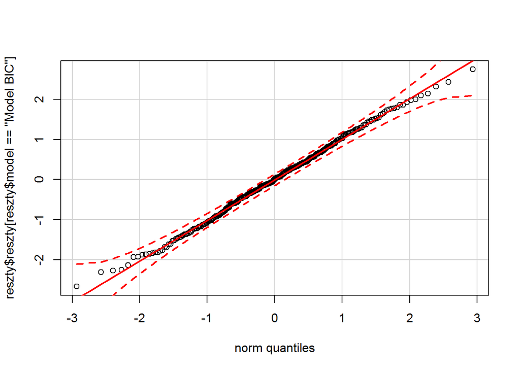

```r
qqPlot(reszty$reszty[reszty$model == "Model BIC"])
```

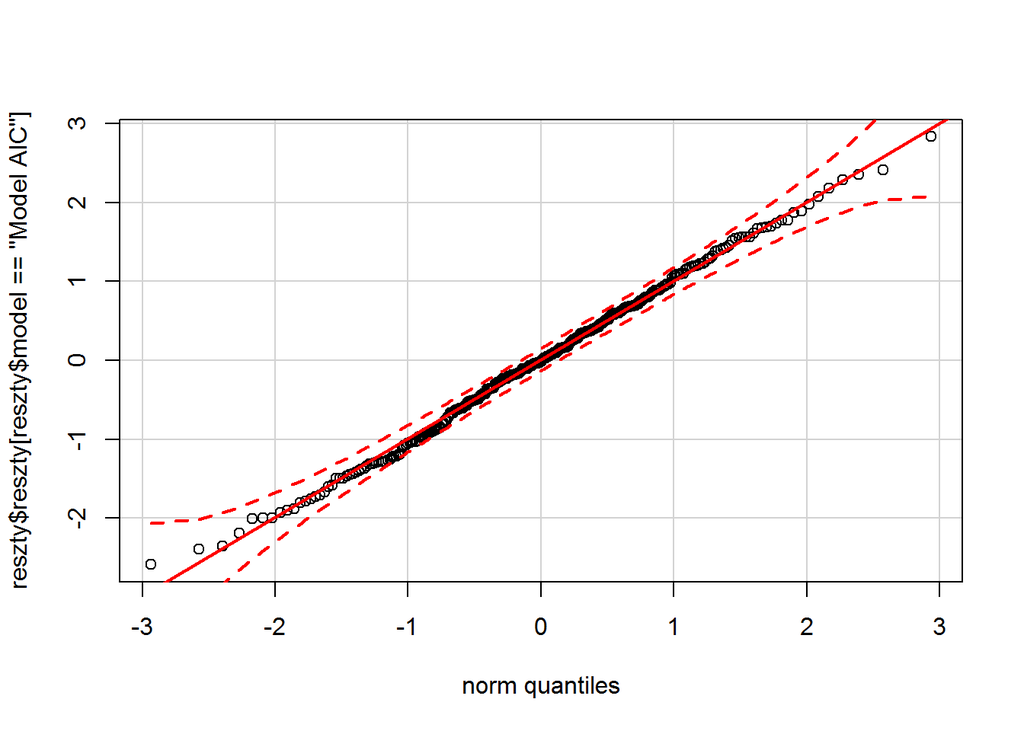

```r
qqPlot(reszty$reszty[reszty$model == "Model AIC"])
```

Na każdym z powyższych wykresów obserwacje znajdują się wewnątrz przedziałów ufności co oznacza brak istotnej rozbieżności względem rozkładu normalnego. Ostatecznie potwierdza to test Shapiro-Wilka:

```r
shapiro.test(reszty$reszty[reszty$model == "Model BIC"])
```

```
##
##  Shapiro-Wilk normality test
##
## data:  reszty$reszty[reszty$model == "Model BIC"]
## W = 0.99727, p-value = 0.8977
```

```r
shapiro.test(reszty$reszty[reszty$model == "Model AIC"])
```

```
##
##  Shapiro-Wilk normality test
##
## data:  reszty$reszty[reszty$model == "Model AIC"]
## W = 0.99713, p-value = 0.8757
```

### Obserwacje wpływowe

Przedstawione poniżej wykresy odległości Cooka pozwalają zidentyfikować obserwacje 53, 127 i 140 jako wpływowe w modelu optymalnym BIC oraz 17, 80 i 278 w modelu wybranym krokowym AIC. Warto zaznaczyć, że w obu przypadkach odległość Cooka obserwacji oznaczonych jako wpływowe nie jest przesadnie większa niż dla pozostałych obserwacji.

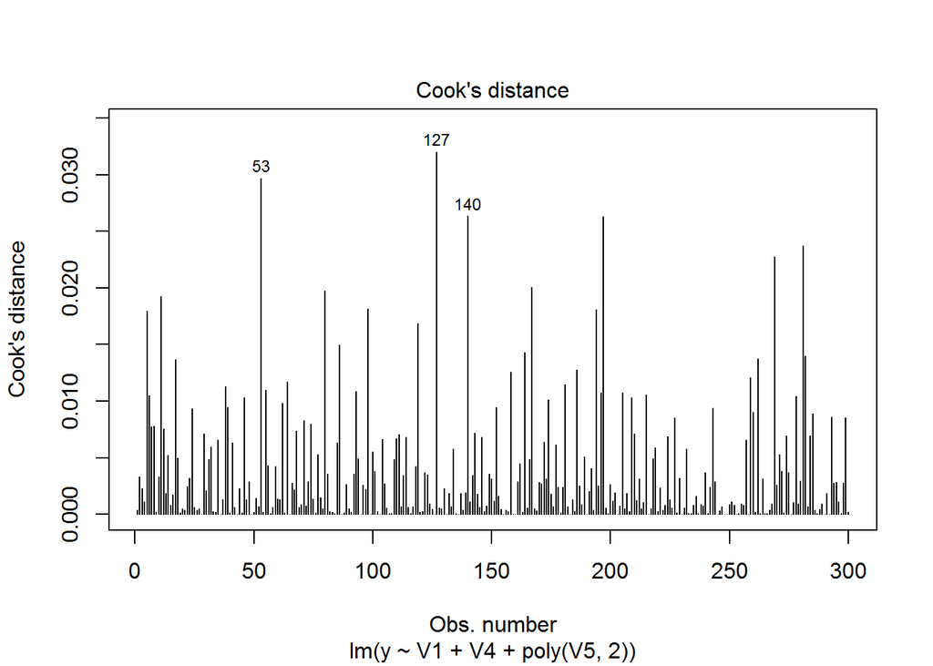

```r
plot(modelBIC, which = 4)
```

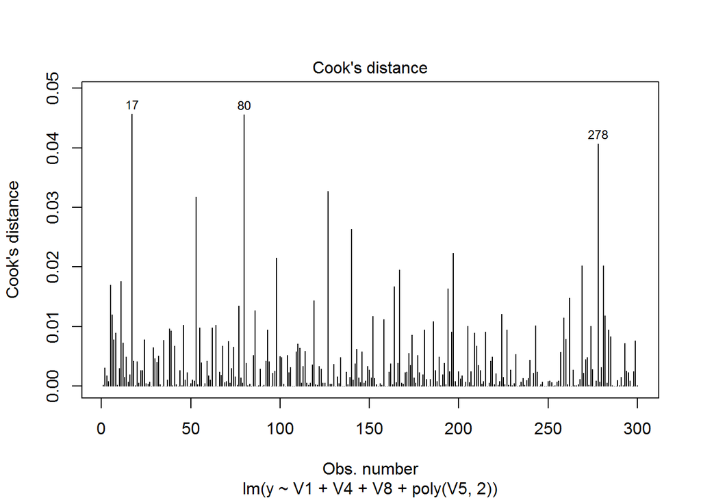

```r
plot(modelAIC, which = 4)
```

### Wniosek

Diagnostyka modelu pozwala stwierdzić, że oba modele są dobre, jednak optymalny wg BIC nie charakteryzuje się problemem niejednorodności wariancji, co ma miejsce w przypadku modelu krokowego AIC.

## 12. Zweryfikuj istotność interakcji `V6` i `V7`.

```r
summary(lm(y ~ V6*V7, data = df))
```

```
##
## Call:
## lm(formula = y ~ V6 * V7, data = df)
##
## Residuals:
##      Min       1Q   Median       3Q      Max
## -16.4046  -9.5194  -0.2421   6.9745  28.7713
##
## Coefficients:
##             Estimate Std. Error t value Pr(>|t|)
## (Intercept)  15.5408     1.1959  12.995   <2e-16 ***
## V6           -0.9772     0.8623  -1.133    0.258
## V7           -1.1173     0.8586  -1.301    0.194
## V6:V7         0.3792     0.6886   0.551    0.582
## ---
## Signif. codes:  0 '***' 0.001 '**' 0.01 '*' 0.05 '.' 0.1 ' ' 1
##
## Residual standard error: 10.46 on 296 degrees of freedom
## Multiple R-squared:  0.009669,   Adjusted R-squared:  -0.0003684
## F-statistic: 0.9633 on 3 and 296 DF,  p-value: 0.4104
```

```r
anova(lm(y ~ V6*V7, data = df))
```

```
## Analysis of Variance Table
##
## Response: y
##            Df Sum Sq Mean Sq F value Pr(>F)
## V6          1    105 105.494  0.9646 0.3268
## V7          1    177 177.389  1.6220 0.2038
## V6:V7       1     33  33.162  0.3032 0.5823
## Residuals 296  32371 109.363
```

Zarówno w teście zwykłym, jak i sekwencyjnym, interakcja między zmiennymi `V6` i `V7` okazuje się być nieistotna.

## 13. Porównaj wyniki z wynikami funkcji `ctree` pakiet `partykit`.

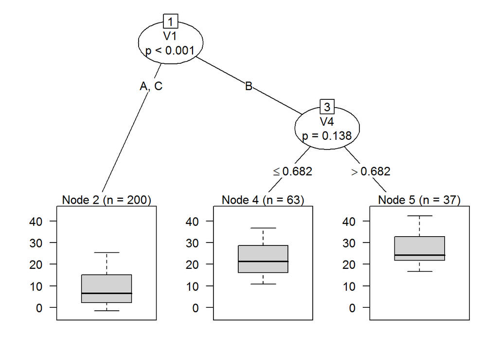

```r
modelCtree <- ctree(y ~ V1 + V4 + poly(V5, 2) + V8, data = df, control = ctree_control(mincriterion = 0.7))
plot(modelCtree)
```

Funkcja `ctree` daje model, w którym istotna jest zmienna `V1` (jej poziomy podzielono na dwie grupy: A i C oraz B). Po modyfikacji kryteriów tworzenia drzewa dostajemy dodatkowy podział względem zmiennej `V4` co przy konstrukcji drzewa jest równoważne interakcji zmiennych `V1` i `V4`, której nie rozpatrywaliśmy przy budowie modeli liniowych.

Dla porównania, poniżej przedstawiamy wyniki estymacji naszych dwóch modeli liniowych:

```r
summary(modelBIC)
```

```
##
## Call:
## lm(formula = y ~ V1 + V4 + poly(V5, 2), data = df)
##
## Residuals:
##     Min      1Q  Median      3Q     Max
## -4.5937 -1.1985  0.0163  1.1776  4.7132
##
## Coefficients:
##              Estimate Std. Error t value Pr(>|t|)
## (Intercept)    6.7874     0.2469  27.487  < 2e-16 ***
## V1B           15.3523     0.2490  61.650  < 2e-16 ***
## V1C            0.3004     0.2488   1.208  0.22819
## V4             3.7713     0.3530  10.685  < 2e-16 ***
## poly(V5, 2)1   4.8291     1.7611   2.742  0.00648 **
## poly(V5, 2)2 126.5130     1.7610  71.840  < 2e-16 ***
## ---
## Signif. codes:  0 '***' 0.001 '**' 0.01 '*' 0.05 '.' 0.1 ' ' 1
##
## Residual standard error: 1.753 on 294 degrees of freedom
## Multiple R-squared:  0.9723, Adjusted R-squared:  0.9719
## F-statistic:  2067 on 5 and 294 DF,  p-value: < 2.2e-16
```

```r
summary(modelAIC)
```

```
##
## Call:
## lm(formula = y ~ V1 + V4 + V8 + poly(V5, 2), data = df)
##
## Residuals:
##     Min      1Q  Median      3Q     Max
## -4.4337 -1.1498 -0.0321  1.1798  4.8362
##
## Coefficients:
##              Estimate Std. Error t value Pr(>|t|)
## (Intercept)    6.9465     0.2666  26.058  < 2e-16 ***
## V1B           15.3996     0.2503  61.536  < 2e-16 ***
## V1C            0.3046     0.2482   1.227  0.22069
## V4             3.7523     0.3523  10.650  < 2e-16 ***
## V8            -0.1636     0.1048  -1.561  0.11961
## poly(V5, 2)1   5.0935     1.7649   2.886  0.00419 **
## poly(V5, 2)2 126.4910     1.7568  72.000  < 2e-16 ***
## ---
## Signif. codes:  0 '***' 0.001 '**' 0.01 '*' 0.05 '.' 0.1 ' ' 1
##
## Residual standard error: 1.749 on 293 degrees of freedom
## Multiple R-squared:  0.9726, Adjusted R-squared:  0.972
## F-statistic:  1732 on 6 and 293 DF,  p-value: < 2.2e-16
```

Widać, że w obu tych modelach, podobnie jak w drzewie, poziom B zmiennej `V1` różni się istotnie od bazowego A, w przeciwieństwie do poziomu C. Istotna w modelach liniowych zmienna `V4` (niechętnie) pojawia się w drzewie, natomiast istotny w modelach liniowych wielomian zmiennej `V5` nie pojawia się w drzewie. Jest to prawdopodobnie spowodowane tym, że włączanie kolejnych zmiennych do drzewa jest analogiczne do włączania kolejnych interakcji do modelu liniowego, więc istotność poszczególnych zmiennych w modelu regresji nie przekłada się na ich występowanie w drzewie.